# Part iiiC: Classification model predictions

INFSCI 2595 Final

Ben Stein

4/27/2022

# About this document

In this document, I make predictions with my two top-performing classification models in order to understand trends between the predictors, the predicted outcome, and the inputs.

# Setup

## Libraries and tools

```r
library(tidyverse)
source("./tools.R")
```

## Data

```r
df <- load_project_data(center_and_scale = TRUE, outcome_to_numeric = FALSE) %>%
  select(-response_log)

df %>% glimpse()
```

```
## Rows: 677
## Columns: 36
## $ region   <fct> XX, XX, XX, XX, XX, XX, XX, XX, XX, XX, XX, XX, XX, XX, XX, X~
## $ customer <fct> B, B, B, B, B, B, B, B, B, B, B, B, B, B, B, B, B, B, B, B, B~
## $ xb_01    <dbl> 0.30863578, -1.17801052, -0.68246175, -0.42477639, -0.4107092~
## $ xb_02    <dbl> -0.52769021, -1.43287502, -1.13114675, 1.58440769, 0.07576633~
## $ xb_03    <dbl> 0.92465680, -0.07214679, 0.26012107, -2.39802182, -0.73668251~
## $ xn_01    <dbl> 0.82042446, 0.25145112, 0.25145112, -0.01406977, -0.40929211,~
## $ xn_02    <dbl> -0.2245211, -0.5623007, 0.1132584, 1.8021561, -0.2245211, 1.4~
## $ xn_03    <dbl> 1.2762480, 0.9010765, 0.1507336, -0.9747808, -1.3499523, -0.5~
## $ xa_01    <dbl> 1.00106429, -1.29333076, 0.23626594, -0.25320501, -0.41340148~
## $ xa_02    <dbl> -0.1773302, -1.4605523, -0.6050709, 2.2465338, 0.5355710, 0.6~
## $ xa_03    <dbl> 1.4593153, -0.1494432, 0.9230625, -1.9369527, -1.0431979, -0.~
## $ xb_04    <dbl> 0.26039081, -0.22110912, -0.22110912, -0.37271282, 0.10351502~
## $ xb_05    <dbl> 0.86178234, 0.55137413, 0.55137413, -2.24229976, -0.84546282,~
```

[output cut: 23 more lines]

## Models to evaluate

I chose two of the top-performing models from iiiA to look at here. Models 2, 3, and 9 all performed well, so I chose 3 and 9. 3 has all predictors, so we can look at a couple of different combinations of important variables, and 9 focuses specifically on the sentiment predictors.

```r
glm_model3 <- load_model("glm_model3.rds")
glm_model9 <- load_model("glm_model9.rds")
```

## Variables of interest

Based on analysis from iiiA2, strong features were the categoricals, some of the NRC lexicon predictors, and `xb_07`, which was also a good predictor in regression models. I’ll examine combinations of these for these models as appropriate.

## Visualization code

The task we’re doing here is similar to Homework 11, so we can mostly reuse the function that creates the visualization grid:

```r
make_test_input_grid <- function(all_input_names, top_4_inputs, all_data)
{
  test_list <- purrr::map(
    all_input_names,
    make_test_input_list,
    top_4_inputs = top_4_inputs,
    all_data = all_data)

  expand.grid(
    test_list,
    KEEP.OUT.ATTRS = FALSE,
    stringsAsFactors = FALSE) %>%
    purrr::set_names(all_input_names)
}
```

However, we have to adapt `make_test_input_list` to accommodate the case where faceting variables are categorical. I made a section version of it that allows you to pass faceting variables separately:

```r
make_test_input_list <- function(var_name, top_4_inputs, all_data)
{
  xvar <- all_data %>% select(var_name) %>% pull()

  if (var_name %in% top_4_inputs[1:2]){
    # use 25 unique values between the min/max values
    xgrid <- seq(min(xvar), max(xvar), length.out = 25)
  } else if (var_name %in% top_4_inputs[3:4]){
    if (is.factor(xvar)) {
      xgrid <- levels(xvar)
    } else {
      # specify quantiles to use
      xgrid <- quantile(xvar, probs = c(0.05, 0.25, 0.5, 0.75, 0.95), na.rm = TRUE)
      xgrid <- as.vector(xgrid)
    }
  } else if (is.numeric(xvar)) {
    # set to their median values
    xgrid <- median(xvar, na.rm = TRUE)
  }
  else if (is.factor(xvar)) {
    # for categoricals, use the mode
    xgrid <- names(which.max(table(xvar)))
  }

  return(xgrid)
}
```

# Examining model prediction trends

## Model 3

Model 3 includes all predictors, so I want to look at how the very important region and customer predictors interact with top sentiment predictors.

```r
glm_model3_viz_grid <- make_test_input_grid(
  all_input_names = df %>% select(-outcome) %>% names,
  top_4_inputs = c(
    "xb_07",
    "xn_08",
    "customer",
    "region"

  ),
  all_data = df
)
```

```
## Note: Using an external vector in selections is ambiguous.
## i Use `all_of(var_name)` instead of `var_name` to silence this message.
## i See <https://tidyselect.r-lib.org/reference/faq-external-vector.html>.
```

```r
glm_model3_preds <- predict(glm_model3, glm_model3_viz_grid)
```

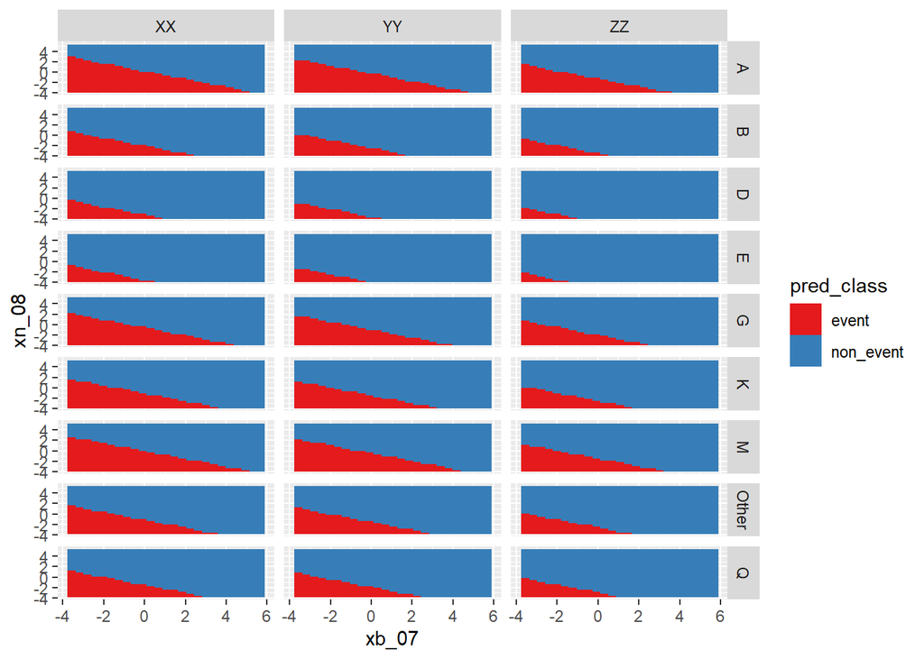

```r
glm_model3_viz_grid %>%
  mutate(pred_class = glm_model3_preds) %>%
  ggplot(mapping = aes(x = xb_07, y = xn_08)) +
  geom_raster(mapping = aes(fill = pred_class)) +
  facet_grid(customer ~ region) +
  scale_fill_brewer(palette = "Set1")
```

Some of the grid properties of this visualization are less useful because the regions and customers are not ordinal. However, they show the degree and direction of how these important predictors affect customers in various regions. As we see in the figure, incidence of the event are higher with customers A, G, and M, and it also occurs more often in region `XX`. We can also observe that holding non-visualized variables constant, the event is associated with low values of `xb_07` and `xn_08`, suggesting the value of (some) sentiment variables as predictors.

## Model 9

Model 9 contains only sentiment-related variables. Thus, all the variables I’m faceting by are continuous. Let’s examine top sentiment variables from this model.

```r
glm_model9_viz_grid <- make_test_input_grid(
  all_input_names = df %>% select(-outcome, -region, -customer) %>% names,
  top_4_inputs = c(
    "xw_03",
    "xa_01",
    "xn_04",
    "xa_04"

  ),
  all_data = df
)

glm_model9_preds <- predict(glm_model9, glm_model9_viz_grid)
```

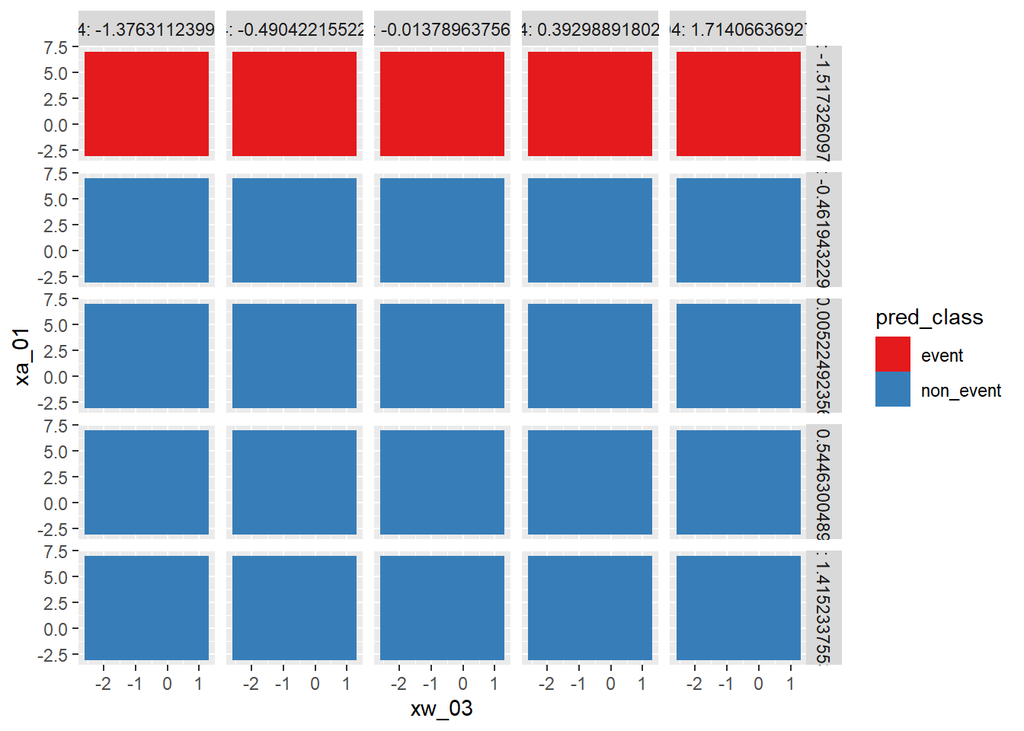

```r
glm_model9_viz_grid %>%
  mutate(pred_class = glm_model9_preds) %>%
  ggplot(mapping = aes(x = xw_03, y = xa_01)) +
  geom_raster(mapping = aes(fill = pred_class)) +
  facet_grid(rows = vars(xn_04), cols = vars(xa_04), labeller = label_both) +
  scale_fill_brewer(palette = "Set1")
```

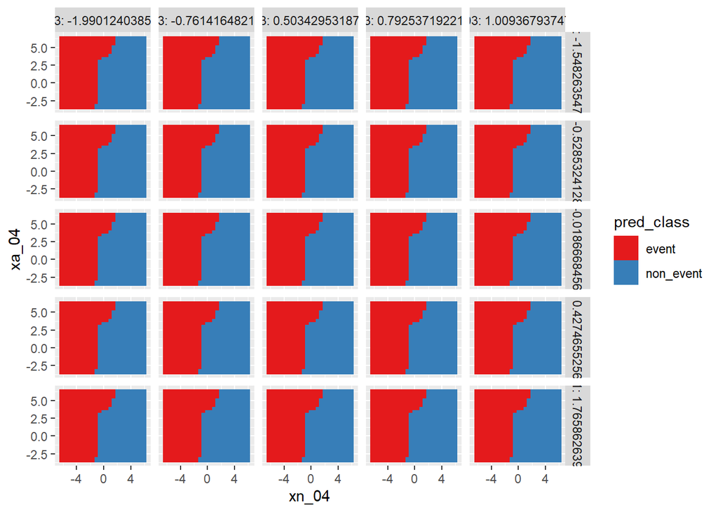

```r
glm_model9_viz_grid_b <- make_test_input_grid(
  all_input_names = df %>% select(-outcome, -region, -customer) %>% names,
  top_4_inputs = c(
    "xn_04",
    "xa_04",
    "xw_03",
    "xa_01"

  ),
  all_data = df
)

glm_model9_preds_b <- predict(glm_model9, glm_model9_viz_grid_b)

glm_model9_viz_grid_b %>%
  mutate(pred_class = glm_model9_preds_b) %>%
  ggplot(mapping = aes(x = xn_04, y = xa_04)) +
  geom_raster(mapping = aes(fill = pred_class)) +
  facet_grid(rows = vars(xa_01), cols = vars(xw_03), labeller = label_both) +
  scale_fill_brewer(palette = "Set1")
```

I know my interpretation of these figures is pretty weak - I have a hard time understanding how the four variables interact when varied all at once.